# Discussion 7: T and Bootstrap Hypothesis test

Henry Mendoza Rivera, UW-Madison, Department of Statistics.

# 1 Problem 1

Biologists studying the healing of skin wounds measured the rate at which new cells closed a cut made in the skin of an anesthetized `newt`. They want to test whether these data are strong evidence that the population mean rate is significantly greater than 25. Here are data from a random sample of 18 newts, measured in micrometers (millionths of a meter) per hour:

$$29, 27, 34, 40, 22, 28, 14, 35, 26, 35, 12, 30, 23, 18, 11, 22, 23, 33$$

- Test the hypothesis using the significance level 0.10.

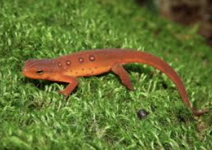

A newt is a salamander in the subfamily Pleurodelinae

## 1.1 Step 1. State the null and alternative hypotheses and the significance level

Identify the claim and use it to construct the null hypothesis and the alternative hypothesis (read lecture notes W7L1).

Click For Answer

1. `Claim`: “The population mean rate is significantly greater than 25.”
2. The random variable $X$ involved in the claim is: The rate at which new cells closed a cut made in the skin of an anesthetized newt.
3. The parameter of interest related to the variable $X$ is: the population mean rate denoted by $\mu$.
4. The claim in symbolic form is: $\mu > 25$ (the population mean rate is significantly `greater than 25`)
5. The claim in symbolic form that must be opposite to the original claim is : $\mu \leq 25$
6. The null hypothesis is $H_0: \mu \leq 25\; micrometers/hour$, and the alternative hypothesis is $H_1: \mu > 25\; micrometers/hour$.

## 1.2 Step 2: Describe the data

Create in R the data vector for the given sample and use the R functions: summary(), hist(), and boxplot() to describe the data.

Click For Answer

- Read the data

```r
rate<-c(29, 27, 34, 40, 22, 28, 14, 35, 26, 35, 12, 30, 23, 18, 11, 22, 23, 33)
```

- Numerical summary.

```r
summary(rate)
```

```
##    Min. 1st Qu.  Median    Mean 3rd Qu.    Max.
##   11.00   22.00   26.50   25.67   32.25   40.00
```

```r
sd(rate)
```

```
## [1] 8.324309
```

The rate is between 11 and 40 micrometers/hour. The mean rate is 25.67 micrometers/hour. The standard deviation is 8.32 micrometers/hour.

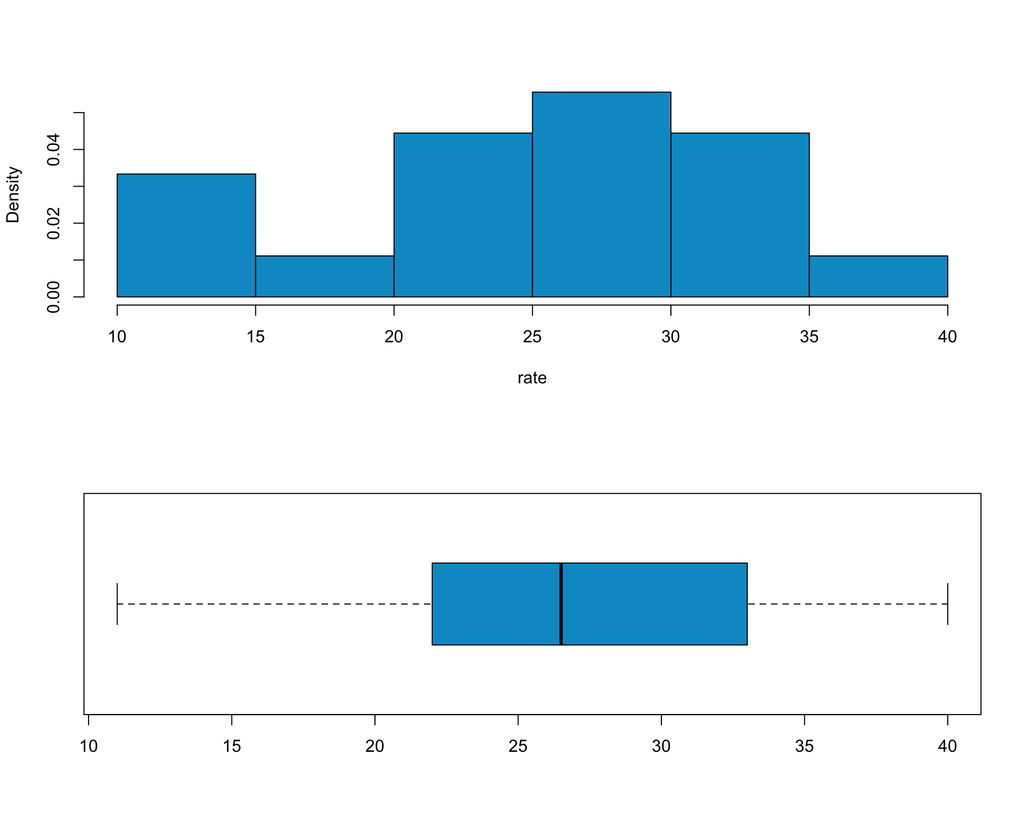

```r
par(mfrow = c(2,1))
hist(rate, main="",col="deepskyblue3",freq = FALSE)

boxplot(rate,horizontal = TRUE,col="deepskyblue3")
```

## 1.3 Step 3. Check assumptions

Evaluate whether the assumptions of the t test are reasonably met.

Click For Answer

- Is the sample a simple random sample?

Yes.

- Is the standard deviation known?

No.

- Is the sample small?

Yes.

- Do the data come from a normal distribution?.

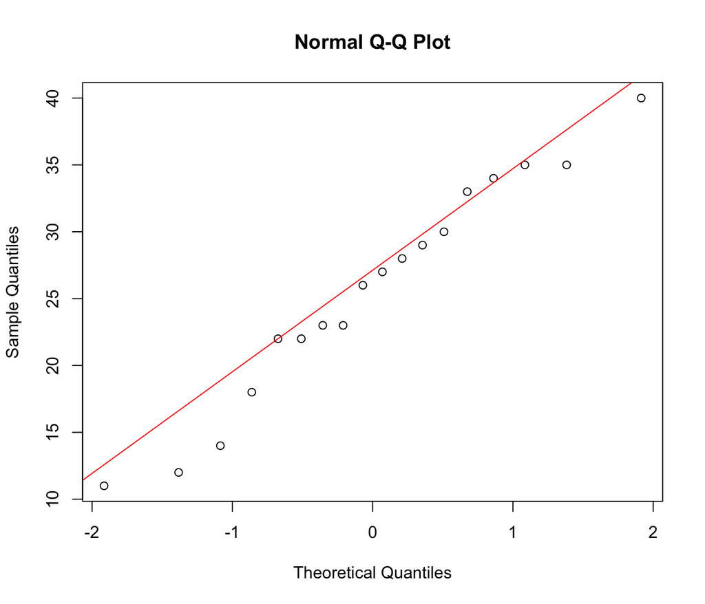

```r
qqnorm(rate)
qqline(rate,col="red")
```

A QQplot is especially important because it would be advantageous if the distribution seemed normal. `There is no reason to question normality` for this data.

## 1.4 Step 4. Perform the appropriated test statistic and take the decision

Click For Answer

In this case, a good choice is the $T$-statistic that we have seen before. This statistics is the right choice because

1. We do not know the standard deviation.
2. The sample size is small.
3. The normality assumptions met.

$$\bbox[#ffcc99,20px,border:10px ligth red]
{
T = \frac{\bar{X} - \mu_{0}}{\frac{S}{\sqrt{n}}} \sim T_{(n-1)}
}$$

$\mu_{0}$ is the general notation for the value of $\mu$ under the null hypothesis, which in this case is 25 micrometers/hour. Values of $t$ that are farther from `0` indicate relatively more evidence against the null.

To decide on the null hypothesis, we can use either of the following methods:

`Method 1: Rejection region.`

Since $\alpha = 0.10$, we put the all $\alpha$ in the right tail of the distribution.

The rejection region is defined by:

$$T \geq t_{(n-1,\alpha)}$$

```r
qt(0.95, 17)
```

```
## [1] 1.739607
```

Our observed test statistic is:

$$t_{obs} = \frac{25.66667 - 25}{\frac{8.324309}{\sqrt{18}}} = 0.3397792.$$

In R:

```r
tobs<-(mean(rate)-25)/(sd(rate)/sqrt(18))
tobs
```

```
## [1] 0.3397792
```

This value does not fall in the rejection region, so we `do not reject the null.` Note that this does not necessarily mean that we are very sure that $\mu \leq 25\; micrometers/hour$. It only means that we `do not have sufficient evidence to discredit that fact.`

Where $t_{(n-1,\alpha/2)}$ is called the `critical value`. In our case, the critical value $t_{(17,0.95)} = 1.739607$

`Method 2: Method of p-value.`

The second testing method is to compute the p-value. Recall that the p-value is defined to be the probability of the test statistic realizing to a value that is as or more extreme than the one observed when the null hypothesis is true. In this example, our observed test statistic $t_{obs}$ was 0.3397792, so the p-value is:

In R:

```r
pt(tobs,df=17,lower.tail = FALSE)
```

```
## [1] 0.3690923
```

- Notice that the p-value consists of the `area to the right` of the observed statistic’s value.
- Since our $\alpha = 0.10$,and $0.3690923 > 0.10$, we `would not reject the null`. There is not enough statistical evidence to say that the mean rate in the wets population is greater than 25 micrometers/hour.

```r
t.test(rate,alternative = "greater",mu = 25, conf.level = 0.90)
```

```
##
##  One Sample t-test
##
## data:  rate
## t = 0.33978, df = 17, p-value = 0.3691
## alternative hypothesis: true mean is greater than 25
## 90 percent confidence interval:
##  23.0505     Inf
## sample estimates:
## mean of x
##  25.66667
```

`Method 2: Method of Confidence Interval`

- We `cannot` use a two-sided confidence interval to test the hypothesis. We could use a one-sided confidence interval, but we won’t study it in this course.

## 1.5 Step 5. State the conclusion and interpret the decision

` Click For Answer

We do not have enough evidence to say that the mean rate in the population of wets is greater than 25 micrometers/hour.

# 2 Problem 2

1. Go to https://shiny.stat.ncsu.edu/jbpost2/NormalPower/ (`Open in New Tab`). Click on `Application` (left side)
2. Set Null mean: $H_0:1.5$
3. Set Alternative mean: $H_0:1.4$
4. Set true Standard deviation: 0.4
5. Set Sample Size: 16
6. Set Alternative Relationship: Not equal
7. Set Significance level: 0.005 ($\alpha/2=0.01/2$)

The $\beta$ is

Click For Answer

$\beta=0.9423$

and the power, $1-\beta$ is

Click For Answer

$1-\beta=0.0577$

8. Keep the same values in 2-6 and set Significance level: 0.025 ($\alpha/2=0.05/2$)

The $\beta$ is

Click For Answer

$\beta=0.8299$

and the power, $1-\beta$ is

Click For Answer

$1-\beta=0.1701$

9. Keep the same values in 2-6 and set Significance level: 0.05 ($\alpha/2=0.10/2$)

The $\beta$ is

Click For Answer

$\beta=0.7364$

and the power, $1-\beta$ is

Click For Answer

$1-\beta=0.2636$

10. Keep the same values 2-6 except Sample Size. Now, Set Sample Size: 126, and repeat steps 7-9.
11. Complete the table.

|  |  | n=16 |  | n=126 |  |
| --- | --- | --- | --- | --- | --- |
| $\alpha$ | $\alpha/2$ | $\beta$ | $1-\beta$ | $\beta$ | $1-\beta$ |
| 0.01 | 0.005 |  |  |  |  |
| 0.05 | 0.025 |  |  |  |  |
| 0.10 | 0.05 |  |  |  |  |

12. Make your conclusions
- For a fixed value of Significance level, when the Sample Size increases, the power _____________________________________ (decreases/increases)
- For a fixed Sample Size, when the Significance level increases, the $\beta$ __________________ (decreases/increases) and the power _____________________________________ (decreases/increases)